# healthcare - Project 1- predict the condition of the patient

```python
import pandas as pd
import numpy as np
import matplotlib.pyplot as plt
import seaborn as sns
from sklearn.model_selection import train_test_split
from sklearn.neighbors import KNeighborsClassifier
from scipy.stats import zscore
from sklearn.metrics import classification_report,confusion_matrix,accuracy_score
from sklearn.model_selection import GridSearchCV
from sklearn.metrics import  make_scorer
from sklearn.metrics import recall_score,precision_score
```

```python
df1 = pd.read_csv("Part1 - Normal.csv")
df2 = pd.read_csv("Part1 - Type_H.csv")
df3 = pd.read_csv("Part1 - Type_S.csv")
```

### Exploring size and shape of each dataframe

```python
print("\n\n Dataframe 1 of shape",df1.shape)
print(df1.head())
print("\n\n Dataframe 2 of shape",df2.shape)
print(df2.head())
print("\n\n Dataframe 3 of shape",df3.shape)
print(df3.head())
```

```
 Dataframe 1 of shape (100, 7)
   P_incidence     P_tilt    L_angle    S_slope    P_radius  S_Degree   Class
0    38.505273  16.964297  35.112814  21.540976  127.632875  7.986683  Normal
1    54.920858  18.968430  51.601455  35.952428  125.846646  2.001642  Normal
2    44.362490   8.945435  46.902096  35.417055  129.220682  4.994195  Normal
3    48.318931  17.452121  48.000000  30.866809  128.980308 -0.910941  Normal
4    45.701789  10.659859  42.577846  35.041929  130.178314 -3.388910  Normal


 Dataframe 2 of shape (60, 7)
   P_incidence     P_tilt    L_angle    S_slope    P_radius   S_Degree   Class
0    63.027818  22.552586  39.609117  40.475232   98.672917  -0.254400  Type_H
1    39.056951  10.060991  25.015378  28.995960  114.405425   4.564259  Type_H
2    68.832021  22.218482  50.092194  46.613539  105.985135  -3.530317  Type_H
3    69.297008  24.652878  44.311238  44.644130  101.868495  11.211523  Type_H
4    49.712859   9.652075  28.317406  40.060784  108.168725   7.918501  Type_H


 Dataframe 3 of shape (150, 7)
   P_incidence     P_tilt    L_angle    S_slope    P_radius   S_Degree   Class
0    74.377678  32.053104  78.772013  42.324573  143.560690  56.125906  Type_S
1    89.680567  32.704435  83.130732  56.976132  129.955476  92.027277  Type_S
2    44.529051   9.433234  52.000000  35.095817  134.711772  29.106575  Type_S
3    77.690577  21.380645  64.429442  56.309932  114.818751  26.931841  Type_S
4    76.147212  21.936186  82.961502  54.211027  123.932010  10.431972  Type_S
```

### • Merge all datasets onto one and explore final shape, size and Null values

```python
df1['Class']='N'
df2['Class']='H'
df3['Class']='S'
print("Coverting Class feature as category")
df_p1 = df1.append(df2)
df_p1 =df_p1.append(df3)
df_p1['Class'] = df_p1.Class.astype('category')




print("\n\n\n if Dataframe has -0- ")
print(df_p1.eq(0).sum())
print("\n\n\n if Dataframe has null value ")
print(df_p1.isnull().sum())
print("\n\n\n value count of classes")
print(df_p1['Class'].value_counts())
print("\n\n dtype of dataframe")
print(df_p1.dtypes)
print("\n\n\n Describe dataframe")
print(df_p1.describe())
print("\n\n\n  Dataframe has no null values and classes are imbalanced")
```

```
Coverting Class feature as category



 if Dataframe has -0-
P_incidence    0
P_tilt         0
L_angle        0
S_slope        0
P_radius       0
S_Degree       0
Class          0
dtype: int64



 if Dataframe has null value
P_incidence    0
P_tilt         0
L_angle        0
S_slope        0
P_radius       0
S_Degree       0
Class          0
dtype: int64



 value count of classes
S    150
N    100
H     60
Name: Class, dtype: int64


 dtype of dataframe
P_incidence     float64
P_tilt          float64
L_angle         float64
S_slope         float64
P_radius        float64
S_Degree        float64
Class          category
dtype: object



 Describe dataframe
       P_incidence      P_tilt     L_angle     S_slope    P_radius    S_Degree
count   310.000000  310.000000  310.000000  310.000000  310.000000  310.000000
mean     60.496653   17.542822   51.930930   42.953831  117.920655   26.296694
std      17.236520   10.008330   18.554064   13.423102   13.317377   37.559027
min      26.147921   -6.554948   14.000000   13.366931   70.082575  -11.058179
25%      46.430294   10.667069   37.000000   33.347122  110.709196    1.603727
50%      58.691038   16.357689   49.562398   42.404912  118.268178   11.767934
75%      72.877696   22.120395   63.000000   52.695888  125.467674   41.287352
max     129.834041   49.431864  125.742385  121.429566  163.071041  418.543082



  Dataframe has no null values and classes are imbalanced
```

### statistical analysis

### one way anovo

```
aov_table              df        sum_sq      mean_sq          F        PR(>F)
Class       2.0   5425.586931  2712.793466  16.866935  1.121996e-07
Residual  307.0  49376.345258   160.835001        NaN           NaN


reject null hypothesis :The mean of the dependent variable same among the Classes.
```

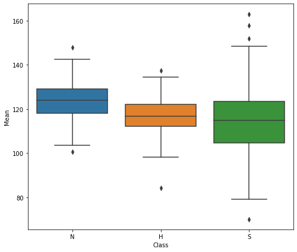

```python
s1_df = df_p1

mean_df = pd.DataFrame()
NY= pd.DataFrame({'Class' : 'N', 'Mean' : s1_df[s1_df.Class.eq('N')].P_radius })
SF = pd.DataFrame({'Class' : 'H', 'Mean' :  s1_df[s1_df.Class.eq('H')].P_radius })

EU = pd.DataFrame({'Class' : 'S', 'Mean' : s1_df[s1_df.Class.eq('S')].P_radius })

mean_df = mean_df.append(NY)
mean_df = mean_df.append(SF)
mean_df = mean_df.append(EU)
fig, ax = plt.subplots(figsize = (8,7))
sns.boxplot(x = 'Class', y = 'Mean', data = mean_df )
import statsmodels.api as sm
from statsmodels.formula.api import ols
mod = ols ('Mean ~ Class', data = mean_df).fit()
aov_table = sm.stats.anova_lm(mod,typ = 1)
aov_table['PR(>F)'] = aov_table['PR(>F)'].apply(lambda x : float(x))

pval = float( "{:.7f}". format(aov_table.loc['Class','PR(>F)']))

print("aov_table",aov_table)

if pval<0.05:
    print("\n\nreject null hypothesis :The mean of the dependent variable same among the Classes. ")
else:
    print("\n\nfailed to reject null hypothesis : The mean of the dependent variable same among the Classes.")
```

```python
import statistics
from scipy import stats

import statistics
print("varaince is not equal",statistics.variance(s1_df[s1_df['Class'] == 'N'].S_slope),
     statistics.variance (s1_df[s1_df['Class'] == 'H'].S_slope)
     )
s1_sam_avg= s1_df[s1_df['Class'] == 'H'].S_slope.mean()
s1_sam2_avg = s1_df[s1_df['Class'] == 'N'].S_slope.mean()
#print(s1_sam_avg,s1_sam2_avg)
#print("t-test is appropriate when the size of the sample is not more than 30 units")
##T Test
stat,pvalue = stats.ttest_ind(s1_df[s1_df['Class'] == 'H'].S_slope, s1_df[s1_df['Class'] == 'S'].S_slope, equal_var = False)

if pvalue<0.05:
    print("reject null hypothesis: S_slope among classes N and H are equal : T Test")
else:
    print("Failed to reject null hypothesis :  S_slope among classes N and H are equal: T Test")
```

```
varaince is not equal 92.62144987611629 57.083883972767325
reject null hypothesis: S_slope among classes N and H are equal : T Test
```

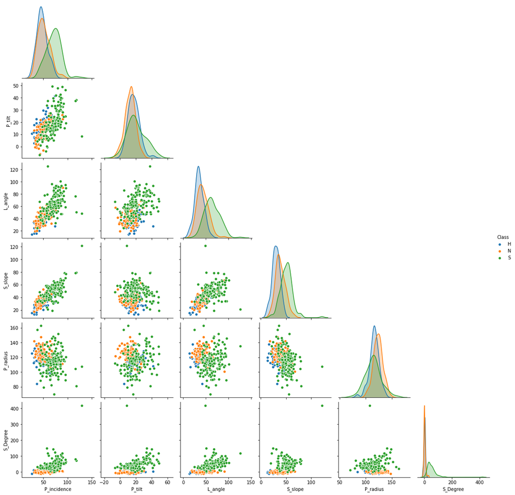

```python
sns.pairplot(df_p1,hue = 'Class',corner=True)
```

- L_Slope and P_incidenace - L_angle and P_incidence - S_slope and P_incidence - are positevly correlated
- data points of Class S are spread out more than Class N and Class H

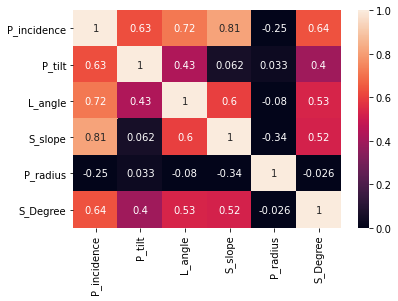

```python
sns.heatmap(data = df_p1.corr(),vmin=0, vmax=1, annot=True)
```

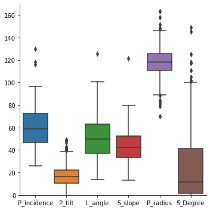

```python
g = sns.catplot(data = df_p1, kind ='box')
g.set(ylim=(0, 170))
```

- features P_incidence P_tilt L_angle S_slope P_radius S_Degree has outliers
- KNN works fine even with outliers,, hence Not dropping outliers

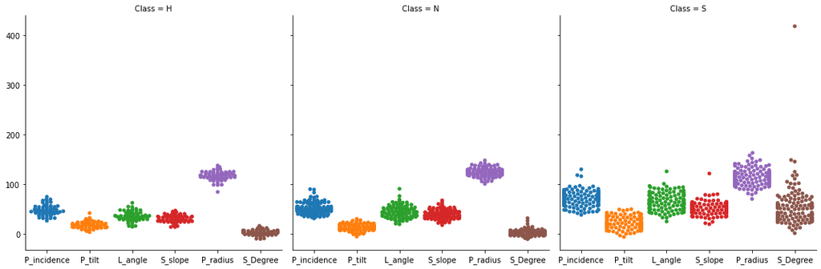

```python
g= sns.catplot(data = df_p1, col = 'Class', kind = 'swarm')
```

- P_incidence seems to vary significantly With respect to classes

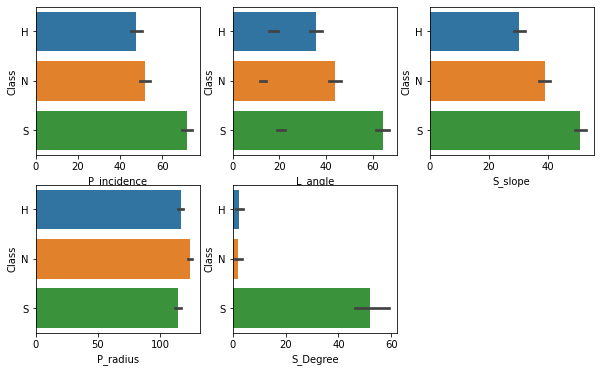

```python
fig_dim = (10,6)
fig, ax = plt.subplots(figsize = (fig_dim))

plt.subplot(2,3,1)
sns.barplot(  data=df_p1, x = 'P_incidence', y="Class",dodge=False)
plt.subplot(2,3,2)



sns.barplot(  data=df_p1,  x = 'P_tilt', y ="Class",dodge=False)
plt.subplot(2,3,2)

sns.barplot(  data=df_p1,  x = 'L_angle', y ="Class",dodge=False)
plt.subplot(2,3,3)
sns.barplot(  data=df_p1,  x = 'S_slope', y ="Class",dodge=False)


plt.subplot(2,3,4)
sns.barplot(  data=df_p1,  x = 'P_radius', y ="Class",dodge=False)
plt.subplot(2,3,5)
sns.barplot(  data=df_p1,  x = 'S_Degree', y ="Class",dodge=False)
```

- P_radius seems to have almost same value across classes - N,H,S
- S_degree has a drastic change of value for class -N,H,S
- P_incidence , L_angle and S_slope seems have same rage for classes - N and H

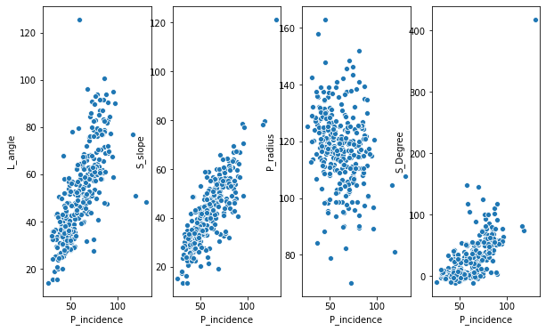

```python
fig_dim = (10,6)
fig, ax = plt.subplots(figsize = (fig_dim))
plt.subplot(1,4,1)
sns.scatterplot(x = 'P_incidence', y = 'L_angle', data = df_p1)
plt.subplot(1,4,2)
sns.scatterplot(x = 'P_incidence', y = 'S_slope', data = df_p1)
plt.subplot(1,4,3)
sns.scatterplot(x = 'P_incidence', y = 'P_radius', data = df_p1)
plt.subplot(1,4,4)
sns.scatterplot(x = 'P_incidence', y = 'S_Degree', data = df_p1)
```

### Data pre-processing - Label Encoding of a class

```python
from sklearn.preprocessing import LabelEncoder
le = LabelEncoder()
df_p1['Class'] =le.fit_transform(df_p1['Class'])
print(df_p1['Class'].value_counts())
```

```
2    150
1    100
0     60
Name: Class, dtype: int64
```

### Data pre-processing - Segregate predictors vs target attributes

```python
X = df_p1.drop(labels= "Class" , axis = 1)
y_scaled = df_p1["Class"]
print(X.head())
#print(y_scaled.head())
```

```
   P_incidence     P_tilt    L_angle    S_slope    P_radius  S_Degree
0    38.505273  16.964297  35.112814  21.540976  127.632875  7.986683
1    54.920858  18.968430  51.601455  35.952428  125.846646  2.001642
2    44.362490   8.945435  46.902096  35.417055  129.220682  4.994195
3    48.318931  17.452121  48.000000  30.866809  128.980308 -0.910941
4    45.701789  10.659859  42.577846  35.041929  130.178314 -3.388910
```

### Data pre-processing - Perform Scaling

```python
#XScaled  = X.apply(zscore)  # convert all attributes to Z scale

#XScaled.describe()
from sklearn.preprocessing import StandardScaler

scaler = StandardScaler()
XScaled =scaler.fit_transform(X)
print("y shape",y_scaled.shape,"X shape",XScaled .shape)
```

```
y shape (310,) X shape (310, 6)
```

### Data pre-processing - Target Balancing

```python
from imblearn.over_sampling import SMOTE
sm = SMOTE(random_state = 2)
XScaled , y_scaled = sm.fit_sample(XScaled , y_scaled)
df_smote_over = pd.concat([pd.DataFrame(XScaled), pd.DataFrame( y_scaled, columns=['Class'])], axis=1)
print("value count of class after smote",df_smote_over['Class'].value_counts())
```

```
value count of class after smote 2    150
1    150
0    150
Name: Class, dtype: int64
```

```
No handles with labels found to put in legend.
No handles with labels found to put in legend.
```

```
Class - Value count with SMOTE vs Class - Value count with out SMOTE
```

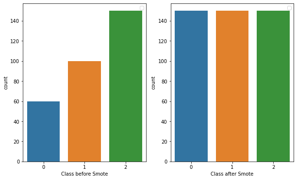

```python
fig_dim = (10,6)
fig, ax = plt.subplots(figsize = (fig_dim))

print("Class - Value count with SMOTE vs Class - Value count with out SMOTE ")
plt.subplot(1,2,1)
sns.countplot(data =df_p1, x ='Class')
plt.xlabel("Class before Smote")
plt.legend()

plt.subplot(1,2,2)
sns.countplot(data =df_smote_over, x ='Class')
plt.xlabel('Class after Smote')

plt.legend()
plt.show()
```

### Data pre-processing - Perform train-test split.

```python
  X_train, X_test, y_train, y_test = train_test_split(XScaled, y_scaled, test_size=0.3, random_state=1)
```

```python
  X_train.shape, X_test.shape, y_train.shape, y_test.shape
```

```
((315, 6), (135, 6), (315,), (135,))
```

### Design and train a KNN classifier

```
NNH SCORE for this model 0.8888888888888888
Confusion Matrix
```

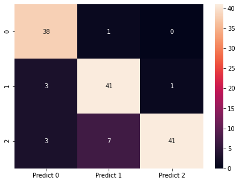

```python
NNH = KNeighborsClassifier(metric= 'manhattan', n_neighbors = 5, weights='distance')
NNH.fit(X_train, y_train)
predicted_labels = NNH.predict(X_test)
print("NNH SCORE for this model",NNH.score(X_test, y_test))

print("Confusion Matrix")
cm=confusion_matrix(y_test, predicted_labels, labels=[0,1,2])

df_cm = pd.DataFrame(cm, index = [i for i in [0,1,2]],
                  columns = [i for i in ["Predict 0","Predict 1","Predict 2"]])
plt.figure(figsize = (7,5))
sns.heatmap(df_cm, annot=True)
```

### Display the classification accuracies for train and test data

```python
print("Train Accuracy:",NNH.score(X_train, y_train)*100)
print("Test Accuracy:",NNH.score(X_test, y_test)*100)
```

```
Train Accuracy: 100.0
Test Accuracy: 88.88888888888889
```

- This model is overfit, thats why it returned train accuracy of 100 and test accuracy of 88. lets try grid search to find the best parameter

### Display and explain the classification report in detail.

```python
print(classification_report(y_test, predicted_labels,labels=[0, 1, 2]))
```

```
              precision    recall  f1-score   support

           0       0.86      0.97      0.92        39
           1       0.84      0.91      0.87        45
           2       0.98      0.80      0.88        51

    accuracy                           0.89       135
   macro avg       0.89      0.90      0.89       135
weighted avg       0.90      0.89      0.89       135
```

- High scores for both Precision and Recall show that the classifier is returning accurate results (high precision), as well as returning a majority of all positive results (high recall).

### Automate the task of finding best values of K for KNN.

```
maximum score 0.9111111111111111
```

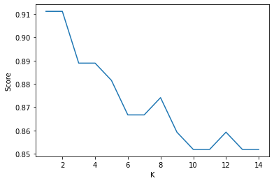

```python
scores =[]
for k in range(1,15):
    NNH = KNeighborsClassifier(n_neighbors = k, weights = 'distance' )
    NNH.fit(X_train, y_train)
    scores.append(NNH.score(X_test, y_test))
print("maximum score",max(scores))
plt.plot(range(1,15),scores)
plt.xlabel('K')
plt.ylabel('Score')
```

- neighbour of 1 gives great accuracy, but it leads to overfitting, we will have to look out for other best parameters

### Hyper tuning

```python
from sklearn.metrics import accuracy_score
X, y = XScaled,y_scaled
# The scorers can be either one of the predefined metric strings or a scorer
# callable, like the one returned by make_scorer
#scorer = make_scorer(recall_score, average = 'weighted')
scoring = { 'Recall': make_scorer(recall_score,labels = [2,0], average='weighted')}

# Setting refit='AUC', refits an estimator on the whole dataset with the
# parameter setting that has the best cross-validated AUC score.
# That estimator is made available at ``gs.best_estimator_`` along with
# parameters like ``gs.best_score_``, ``gs.best_params_`` and
# ``gs.best_index_``
gs = GridSearchCV(KNeighborsClassifier(),
                  param_grid={
    'n_neighbors':[3,5,7,9,11,13,15,17],
    'weights' : ['uniform','distance'],
    'metric' : ['euclidean','manhattan']


},

                  scoring=scoring, refit='Recall', return_train_score=True)
print(scoring)
gs.fit(X, y)

results = gs.cv_results_
print("best index ",gs.best_index_)
print("best_score_",gs.best_score_)
print("best_estimator_",gs.best_estimator_)
print("best_params_",gs.best_params_)
print("best_estimator_",gs.best_estimator_)
#print("n_neighbors",gs_results.n_neighbors_)
```

```
{'Recall': make_scorer(recall_score, labels=[2, 0], average=weighted)}
best index  5
best_score_ 0.9199999999999999
best_estimator_ KNeighborsClassifier(metric='euclidean', n_neighbors=7, weights='distance')
best_params_ {'metric': 'euclidean', 'n_neighbors': 7, 'weights': 'distance'}
best_estimator_ KNeighborsClassifier(metric='euclidean', n_neighbors=7, weights='distance')
```

```python
NNH = KNeighborsClassifier(metric='euclidean', n_neighbors=7, weights='distance')
X_train, X_test, y_train, y_test = train_test_split(XScaled, y_scaled, test_size=0.3, random_state=1)
NNH.fit(X_train, y_train)
predicted_labels = NNH.predict(X_test)
NNH.score(X_test, y_test)
```

```
0.8666666666666667
```

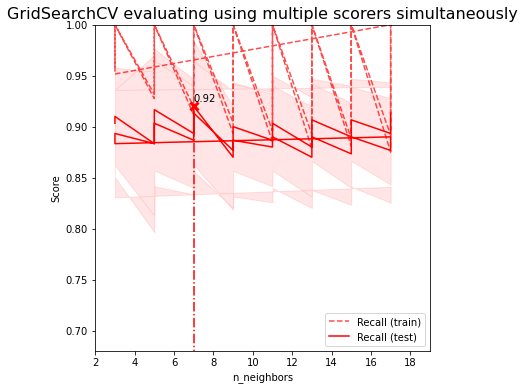

```python
plt.figure(figsize=(6, 6))
plt.title("GridSearchCV evaluating using multiple scorers simultaneously",
          fontsize=16)

plt.xlabel("n_neighbors")
plt.ylabel("Score")

ax = plt.gca()
ax.set_xlim(2, 19)
ax.set_ylim(0.68, 1)

# Get the regular numpy array from the MaskedArray
X_axis = np.array(results['param_n_neighbors'].data, dtype=int)

for scorer, color in zip(sorted(scoring), ['r', 'b']):
    for sample, style in (('train', '--'), ('test', '-')):
        sample_score_mean = results['mean_%s_%s' % (sample, scorer)]
        sample_score_std = results['std_%s_%s' % (sample, scorer)]
        ax.fill_between(X_axis, sample_score_mean - sample_score_std,
                        sample_score_mean + sample_score_std,
                        alpha=0.1 if sample == 'test' else 0, color=color)
        ax.plot(X_axis, sample_score_mean, style, color=color,
                alpha=1 if sample == 'test' else 0.7,
                label="%s (%s)" % (scorer, sample))

    best_index = np.nonzero(results['rank_test_%s' % scorer] == 1)[0][0]
    #best_index1= np.nonzero(results['rank_test_%s' % scorer] == 1)[0][0]
    best_score = results['mean_test_%s' % scorer][best_index]

    # Plot a dotted vertical line at the best score for that scorer marked by x
    ax.plot([X_axis[best_index], ] * 2, [0, best_score],
            linestyle='-.', color=color, marker='x', markeredgewidth=3, ms=8)

   # ax.plot([X_axis[best_index1], ] * 2, [0, best_score],
            #linestyle=':', color=color, marker='*', markeredgewidth=3, ms=8)

    # Annotate the best score for that scorer*
    ax.annotate("%0.2f" % best_score,
                (X_axis[best_index], best_score + 0.005))

plt.legend(loc="best")
plt.grid(False)
plt.show()
```

- Grid Search parameter is designed with a scoring Parameter as Recall
- Recall for class [0 and 2] is metioned to focus on class labels Type H and Type S
- It returned 7 as best parameter, lets check the recall score for class -Type H and Type S
- Our intention is to reduce false Negative rate in Class Type H and Type S
- Cost of Error in False Negative rate for Class Type H and Type S is higher tha Type N

```python
#np.nonzero(results['rank_test_%s' % scorer] == 6)[0]
```

- Using Grid search , we infer that best neighbour is 7 to have a good recall score for the class - Type H and Type S
- created a dictionary to store all the possible k values for all the possible test size and converted to data frame to find the best model

[output not shown]

[output cut: 14 more lines]

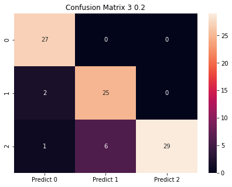

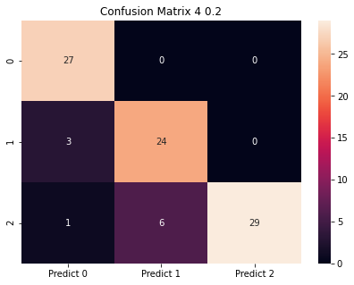

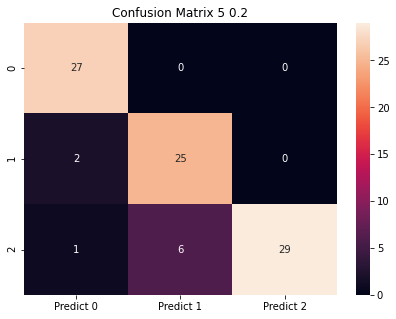

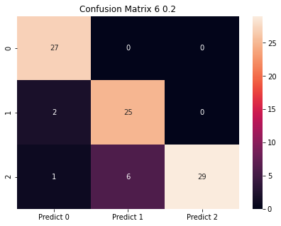

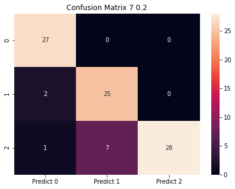

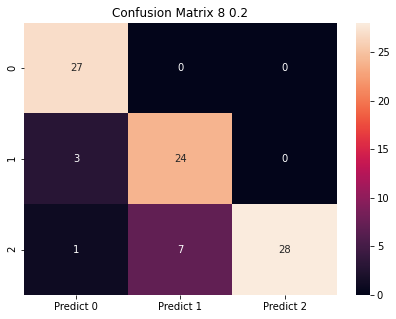

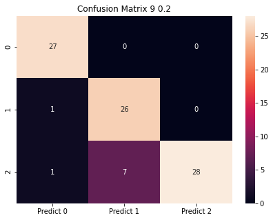

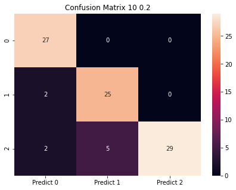

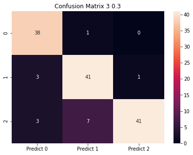

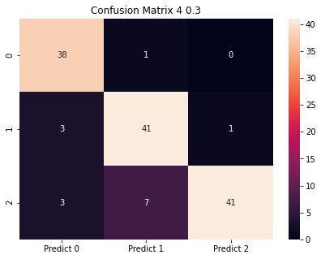

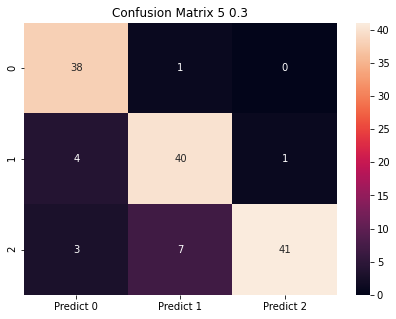

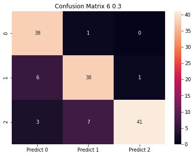

[28 more figures not shown]

```python
score_d = {}
from sklearn.metrics import precision_score, recall_score,roc_curve
from sklearn.metrics import accuracy_score,roc_auc_score
from sklearn.metrics import f1_score
acc = {}
test_size_d ={}
[test_size_d.setdefault(round(x,2), []) for x in np.arange (0.20,0.70,0.10)]
[score_d.setdefault(round(x), []) for x in np.arange (3,7)]
#[acc.setdefault(str(round(x))+'s', []) for x in np.arange (3,7)]
scores = []
Train_scores = []
test_size = []
for i in np.arange (0.20,0.70,0.10):
    test_size.append(round(i,2))
    X_train, X_test, y_train, y_test = train_test_split(XScaled, y_scaled, test_size=round(i,2), random_state=1)
    score_d = {}
    score_Train ={}
    for k in range(3,11):

            NNH = KNeighborsClassifier(n_neighbors = k, weights = 'distance',metric='euclidean')

            NNH.fit(X_train, y_train)
            predicted_labels = NNH.predict(X_test)
            #print()
            scores.append(NNH.score(X_test, y_test))
            score_d[k] = NNH.score(X_test, y_test)
            temp =  score_d
            test_size_d[round(i,2)]=temp

            #Train_scores.append(NNH.score(X_train,y_train))
            #score_Train[k] = NNH.score(X_train, y_train)
            #temp =  score_Train
            #test_size_d[round(i,2)]=temp


            acc[str(k)+'Accuracy'] = accuracy_score(y_test, predicted_labels, normalize=False)
            test_size_d[round(i,2)].update(acc)
            acc[str(k)+'Precision'] = precision_score(y_test, predicted_labels,average=None)
            test_size_d[round(i,2)].update(acc)
            acc[str(k)+'Recall'] = recall_score(y_test, predicted_labels,average=None)
            test_size_d[round(i,2)].update(acc)
            acc[str(k)+'F1-Score'] =  f1_score(y_test,predicted_labels, average='weighted')
            test_size_d[round(i,2)].update(acc)
            acc[str(k)+'Train-Score'] =  NNH.score(X_test, y_test)
            test_size_d[round(i,2)].update(acc)
            #acc[str(k)+'AUC-Score'] = roc_auc_score(y_test, np.transpose([y_pred[:, 1] for y_pred in NNH.predict_proba(X)]), multi_class="ovr",average='weighted')
            #test_size_d[round(i,2)].update(acc)

            #precision_score(y_test, predicted_labels)
            #recall_score(y_test, predicted_labels)
            cm=confusion_matrix(y_test, predicted_labels, labels=[0,1,2])
            #precision_score(y_test, predicted_labels)
            #recall_score(y_test, predicted_labels)

            df_cm = pd.DataFrame(cm, index = [i for i in [0,1,2]],columns = [i for i in ["Predict 0","Predict 1","Predict 2"]])

            TP = np.diag(cm)

            FP = cm.sum(axis=0) - np.diag(cm)
            FN = cm.sum(axis=1) - np.diag(cm)
            #TP = np.diag(cnf_matrix)
           # print(FP,TP)
            TP = TP.astype(float)
            FP = FP.astype(float)
            FN = FP.astype(float)
            #FP = cnf_matrix.sum(axis=0) - np.diag(cnf_matrix)
#FN = cnf_matrix.sum(axis=1) - np.diag(cnf_matrix)
#TP = np.diag(cnf_matrix)
#TN = cnf_matrix.sum() - (FP + FN + TP)
            #print(FP)
            acc[str(k)+'TP'] =  TP
            test_size_d[round(i,2)].update(acc)
            acc[str(k)+'FP'] =  FP
            test_size_d[round(i,2)].update(acc)
            acc[str(k)+'FN'] =  FN
            test_size_d[round(i,2)].update(acc)

            plt.figure(figsize = (7,5))
            sns.heatmap(df_cm, annot=True)
            plt.title("Confusion Matrix "+str(k)+" "+str(round(i,2)))
```

```python
pd.set_option('display.max_rows', None)
pd.DataFrame.from_dict(test_size_d)
```

|  | 0.2 | 0.3 | 0.4 | 0.5 | 0.6 |
| --- | --- | --- | --- | --- | --- |
| 3 | 0.9 | 0.888889 | 0.866667 | 0.817778 | 0.785185 |
| 3Accuracy | 81 | 120 | 156 | 184 | 212 |
| 3Precision | [0.9, 0.8064516129032258, 1.0] | [0.8636363636363636, 0.8367346938775511, 0.976... | [0.9016393442622951, 0.8095238095238095, 0.892... | [0.788235294117647, 0.7702702702702703, 0.9090... | [0.7428571428571429, 0.75, 0.8765432098765432] |
| 3Recall | [1.0, 0.9259259259259259, 0.8055555555555556] | [0.9743589743589743, 0.9111111111111111, 0.803... | [0.9322033898305084, 0.85, 0.819672131147541] | [0.8933333333333333, 0.7702702702702703, 0.789... | [0.8571428571428571, 0.6923076923076923, 0.806... |
| 3F1-Score | 0.899754 | 0.888399 | 0.866534 | 0.817946 | 0.784776 |
| 3Train-Score | 0.9 | 0.888889 | 0.866667 | 0.817778 | 0.785185 |
| 3TP | [27.0, 25.0, 29.0] | [38.0, 41.0, 41.0] | [55.0, 51.0, 50.0] | [67.0, 57.0, 60.0] | [78.0, 63.0, 71.0] |
| 3FP | [3.0, 6.0, 0.0] | [6.0, 8.0, 1.0] | [6.0, 12.0, 6.0] | [18.0, 17.0, 6.0] | [27.0, 21.0, 10.0] |
| 3FN | [3.0, 6.0, 0.0] | [6.0, 8.0, 1.0] | [6.0, 12.0, 6.0] | [18.0, 17.0, 6.0] | [27.0, 21.0, 10.0] |
| 4 | 0.888889 | 0.888889 | 0.866667 | 0.826667 | 0.796296 |
| 4Accuracy | 80 | 120 | 156 | 186 | 215 |
| 4Precision | [0.8709677419354839, 0.8, 1.0] | [0.8636363636363636, 0.8367346938775511, 0.976... | [0.9016393442622951, 0.8095238095238095, 0.892... | [0.7931034482758621, 0.7945205479452054, 0.907... | [0.7387387387387387, 0.7875, 0.8860759493670886] |
| 4Recall | [1.0, 0.8888888888888888, 0.8055555555555556] | [0.9743589743589743, 0.9111111111111111, 0.803... | [0.9322033898305084, 0.85, 0.819672131147541] | [0.92, 0.7837837837837838, 0.7763157894736842] | [0.9010989010989011, 0.6923076923076923, 0.795... |
| 4F1-Score | 0.888865 | 0.888399 | 0.866534 | 0.826161 | 0.795208 |
| 4Train-Score | 0.888889 | 0.888889 | 0.866667 | 0.826667 | 0.796296 |
| 4TP | [27.0, 24.0, 29.0] | [38.0, 41.0, 41.0] | [55.0, 51.0, 50.0] | [69.0, 58.0, 59.0] | [82.0, 63.0, 70.0] |
| 4FP | [4.0, 6.0, 0.0] | [6.0, 8.0, 1.0] | [6.0, 12.0, 6.0] | [18.0, 15.0, 6.0] | [29.0, 17.0, 9.0] |
| 4FN | [4.0, 6.0, 0.0] | [6.0, 8.0, 1.0] | [6.0, 12.0, 6.0] | [18.0, 15.0, 6.0] | [29.0, 17.0, 9.0] |
| 5 | 0.9 | 0.881481 | 0.855556 | 0.8 | 0.774074 |
| 5Accuracy | 81 | 119 | 154 | 180 | 209 |
| 5Precision | [0.9, 0.8064516129032258, 1.0] | [0.8444444444444444, 0.8333333333333334, 0.976... | [0.8615384615384616, 0.8166666666666667, 0.890... | [0.7391304347826086, 0.7794117647058824, 0.907... | [0.7333333333333333, 0.7294117647058823, 0.875] |
| 5Recall | [1.0, 0.9259259259259259, 0.8055555555555556] | [0.9743589743589743, 0.8888888888888888, 0.803... | [0.9491525423728814, 0.8166666666666667, 0.803... | [0.9066666666666666, 0.7162162162162162, 0.776... | [0.8461538461538461, 0.6813186813186813, 0.795... |
| 5F1-Score | 0.899754 | 0.881208 | 0.854582 | 0.799645 | 0.773878 |
| 5Train-Score | 0.9 | 0.881481 | 0.855556 | 0.8 | 0.774074 |
| 5TP | [27.0, 25.0, 29.0] | [38.0, 40.0, 41.0] | [56.0, 49.0, 49.0] | [68.0, 53.0, 59.0] | [77.0, 62.0, 70.0] |
| 5FP | [3.0, 6.0, 0.0] | [7.0, 8.0, 1.0] | [9.0, 11.0, 6.0] | [24.0, 15.0, 6.0] | [28.0, 23.0, 10.0] |
| 5FN | [3.0, 6.0, 0.0] | [7.0, 8.0, 1.0] | [9.0, 11.0, 6.0] | [24.0, 15.0, 6.0] | [28.0, 23.0, 10.0] |
| 6 | 0.9 | 0.866667 | 0.85 | 0.804444 | 0.788889 |
| 6Accuracy | 81 | 117 | 153 | 181 | 213 |
| 6Precision | [0.9, 0.8064516129032258, 1.0] | [0.8085106382978723, 0.8260869565217391, 0.976... | [0.859375, 0.8032786885245902, 0.8909090909090... | [0.7472527472527473, 0.782608695652174, 0.9076... | [0.7363636363636363, 0.7654320987654321, 0.886... |
| 6Recall | [1.0, 0.9259259259259259, 0.8055555555555556] | [0.9743589743589743, 0.8444444444444444, 0.803... | [0.9322033898305084, 0.8166666666666667, 0.803... | [0.9066666666666666, 0.7297297297297297, 0.776... | [0.8901098901098901, 0.6813186813186813, 0.795... |
| 6F1-Score | 0.899754 | 0.86678 | 0.84941 | 0.804163 | 0.787853 |
| 6Train-Score | 0.9 | 0.866667 | 0.85 | 0.804444 | 0.788889 |
| 6TP | [27.0, 25.0, 29.0] | [38.0, 38.0, 41.0] | [55.0, 49.0, 49.0] | [68.0, 54.0, 59.0] | [81.0, 62.0, 70.0] |
| 6FP | [3.0, 6.0, 0.0] | [9.0, 8.0, 1.0] | [9.0, 12.0, 6.0] | [23.0, 15.0, 6.0] | [29.0, 19.0, 9.0] |
| 6FN | [3.0, 6.0, 0.0] | [9.0, 8.0, 1.0] | [9.0, 12.0, 6.0] | [23.0, 15.0, 6.0] | [29.0, 19.0, 9.0] |
| 7 | 0.888889 | 0.866667 | 0.844444 | 0.8 | 0.785185 |
| 7Accuracy | 80 | 117 | 152 | 180 | 212 |
| 7Precision | [0.9, 0.78125, 1.0] | [0.8260869565217391, 0.8163265306122449, 0.975] | [0.859375, 0.7903225806451613, 0.8888888888888... | [0.75, 0.7611940298507462, 0.9090909090909091] | [0.7572815533980582, 0.7209302325581395, 0.888... |
| 7Recall | [1.0, 0.9259259259259259, 0.7777777777777778] | [0.9743589743589743, 0.8888888888888888, 0.764... | [0.9322033898305084, 0.8166666666666667, 0.786... | [0.92, 0.6891891891891891, 0.7894736842105263] | [0.8571428571428571, 0.6813186813186813, 0.818... |
| 7F1-Score | 0.888448 | 0.865798 | 0.843793 | 0.798815 | 0.784848 |
| 7Train-Score | 0.888889 | 0.866667 | 0.844444 | 0.8 | 0.785185 |
| 7TP | [27.0, 25.0, 28.0] | [38.0, 40.0, 39.0] | [55.0, 49.0, 48.0] | [69.0, 51.0, 60.0] | [78.0, 62.0, 72.0] |
| 7FP | [3.0, 7.0, 0.0] | [8.0, 9.0, 1.0] | [9.0, 13.0, 6.0] | [23.0, 16.0, 6.0] | [25.0, 24.0, 9.0] |
| 7FN | [3.0, 7.0, 0.0] | [8.0, 9.0, 1.0] | [9.0, 13.0, 6.0] | [23.0, 16.0, 6.0] | [25.0, 24.0, 9.0] |
| 8 | 0.877778 | 0.874074 | 0.85 | 0.804444 | 0.792593 |
| 8Accuracy | 79 | 118 | 153 | 181 | 214 |
| 8Precision | [0.8709677419354839, 0.7741935483870968, 1.0] | [0.8260869565217391, 0.8297872340425532, 0.976... | [0.835820895522388, 0.8245614035087719, 0.8928... | [0.7666666666666667, 0.7571428571428571, 0.907... | [0.7570093457943925, 0.7469879518072289, 0.8875] |
| 8Recall | [1.0, 0.8888888888888888, 0.7777777777777778] | [0.9743589743589743, 0.8666666666666667, 0.803... | [0.9491525423728814, 0.7833333333333333, 0.819... | [0.92, 0.7162162162162162, 0.7763157894736842] | [0.8901098901098901, 0.6813186813186813, 0.806... |
| 8F1-Score | 0.877586 | 0.874004 | 0.848813 | 0.803566 | 0.79143 |
| 8Train-Score | 0.877778 | 0.874074 | 0.85 | 0.804444 | 0.792593 |
| 8TP | [27.0, 24.0, 28.0] | [38.0, 39.0, 41.0] | [56.0, 47.0, 50.0] | [69.0, 53.0, 59.0] | [81.0, 62.0, 71.0] |
| 8FP | [4.0, 7.0, 0.0] | [8.0, 8.0, 1.0] | [11.0, 10.0, 6.0] | [21.0, 17.0, 6.0] | [26.0, 21.0, 9.0] |
| 8FN | [4.0, 7.0, 0.0] | [8.0, 8.0, 1.0] | [11.0, 10.0, 6.0] | [21.0, 17.0, 6.0] | [26.0, 21.0, 9.0] |
| 9 | 0.9 | 0.859259 | 0.844444 | 0.813333 | 0.803704 |
| 9Accuracy | 81 | 116 | 152 | 183 | 217 |
| 9Precision | [0.9310344827586207, 0.7878787878787878, 1.0] | [0.7916666666666666, 0.8409090909090909, 0.953... | [0.8484848484848485, 0.7966101694915254, 0.890... | [0.7752808988764045, 0.7681159420289855, 0.910... | [0.7788461538461539, 0.7529411764705882, 0.888... |
| 9Recall | [1.0, 0.9629629629629629, 0.7777777777777778] | [0.9743589743589743, 0.8222222222222222, 0.803... | [0.9491525423728814, 0.7833333333333333, 0.803... | [0.92, 0.7162162162162162, 0.8026315789473685] | [0.8901098901098901, 0.7032967032967034, 0.818... |
| 9F1-Score | 0.899286 | 0.859067 | 0.843297 | 0.812454 | 0.80283 |
| 9Train-Score | 0.9 | 0.859259 | 0.844444 | 0.813333 | 0.803704 |
| 9TP | [27.0, 26.0, 28.0] | [38.0, 37.0, 41.0] | [56.0, 47.0, 49.0] | [69.0, 53.0, 61.0] | [81.0, 64.0, 72.0] |
| 9FP | [2.0, 7.0, 0.0] | [10.0, 7.0, 2.0] | [10.0, 12.0, 6.0] | [20.0, 16.0, 6.0] | [23.0, 21.0, 9.0] |
| 9FN | [2.0, 7.0, 0.0] | [10.0, 7.0, 2.0] | [10.0, 12.0, 6.0] | [20.0, 16.0, 6.0] | [23.0, 21.0, 9.0] |
| 10 | 0.9 | 0.851852 | 0.838889 | 0.817778 | 0.803704 |
| 10Accuracy | 81 | 115 | 151 | 184 | 217 |
| 10Precision | [0.8709677419354839, 0.8333333333333334, 1.0] | [0.7755102040816326, 0.8372093023255814, 0.953... | [0.8461538461538461, 0.7833333333333333, 0.890... | [0.7840909090909091, 0.7681159420289855, 0.911... | [0.7714285714285715, 0.7654320987654321, 0.880... |
| 10Recall | [1.0, 0.9259259259259259, 0.8055555555555556] | [0.9743589743589743, 0.8, 0.803921568627451] | [0.9322033898305084, 0.7833333333333333, 0.803... | [0.92, 0.7162162162162162, 0.8157894736842105] | [0.8901098901098901, 0.6813186813186813, 0.840... |
| 10F1-Score | 0.899391 | 0.851773 | 0.838184 | 0.816865 | 0.802 |
| 10Train-Score | 0.9 | 0.851852 | 0.838889 | 0.817778 | 0.803704 |
| 10TP | [27.0, 25.0, 29.0] | [38.0, 36.0, 41.0] | [55.0, 47.0, 49.0] | [69.0, 53.0, 62.0] | [81.0, 62.0, 74.0] |
| 10FP | [4.0, 5.0, 0.0] | [11.0, 7.0, 2.0] | [10.0, 13.0, 6.0] | [19.0, 16.0, 6.0] | [24.0, 19.0, 10.0] |
| 10FN | [4.0, 5.0, 0.0] | [11.0, 7.0, 2.0] | [10.0, 13.0, 6.0] | [19.0, 16.0, 6.0] | [24.0, 19.0, 10.0] |

```python
pd.DataFrame.from_dict(test_size_d).describe()
```

|  | 0.2 | 0.3 | 0.4 | 0.5 | 0.6 |
| --- | --- | --- | --- | --- | --- |
| count | 72.0 | 72.000000 | 72.000000 | 72.000000 | 72.000000 |
| unique | 52.0 | 59.000000 | 57.000000 | 58.000000 | 60.000000 |
| top | 0.9 | 0.888889 | 0.866667 | 0.817778 | 0.785185 |
| freq | 10.0 | 4.000000 | 4.000000 | 4.000000 | 4.000000 |

```python
print(pd.DataFrame.from_dict(test_size_d).T.describe(include = 'all'))
```

```
               3  3Accuracy  \
count   5.000000          5
unique  5.000000          5
top     0.785185        184
freq    1.000000          1

                                               3Precision  \
count                                                   5
unique                                                  5
top     [0.9016393442622951, 0.8095238095238095, 0.892...
freq                                                    1

                                              3Recall  3F1-Score  \
count                                               5   5.000000
unique                                              5   5.000000
top     [0.9322033898305084, 0.85, 0.819672131147541]   0.784776
freq                                                1   1.000000

        3Train-Score                 3TP               3FP               3FN  \
count       5.000000                   5                 5                 5
unique      5.000000                   5                 5                 5
top         0.785185  [55.0, 51.0, 50.0]  [6.0, 12.0, 6.0]  [6.0, 12.0, 6.0]
freq        1.000000                   1                 1                 1

               4  ...                9FN        10 10Accuracy  \
count   5.000000  ...                  5  5.000000          5
unique  4.000000  ...                  5  5.000000          5
top     0.888889  ...  [10.0, 12.0, 6.0]  0.803704        151
freq    2.000000  ...                  1  1.000000          1

                                              10Precision  \
count                                                   5
unique                                                  5
top     [0.8461538461538461, 0.7833333333333333, 0.890...
freq                                                    1

                                                 10Recall 10F1-Score  \
count                                                   5      5.000
unique                                                  5      5.000
top     [0.9322033898305084, 0.7833333333333333, 0.803...      0.802
freq                                                    1      1.000

       10Train-Score                10TP               10FP               10FN
count       5.000000                   5                  5                  5
unique      5.000000                   5                  5                  5
top         0.803704  [55.0, 47.0, 49.0]  [10.0, 13.0, 6.0]  [10.0, 13.0, 6.0]
freq        1.000000                   1                  1                  1

[4 rows x 72 columns]
```

```python
df_metrics = (pd.DataFrame.from_dict(test_size_d).T)
df_metrics.reset_index(inplace=True)
df_metrics['Type_3_H_TP'] = df_metrics['3TP'].apply(lambda x : x[0])
df_metrics['Type_3_H_FP'] = df_metrics['3FP'].apply(lambda x : x[0])
df_metrics['Type_3_H_FN'] = df_metrics['3FN'].apply(lambda x : x[0])


df_metrics['Type_3_S_TP'] = df_metrics['3TP'].apply(lambda x : x[2])
df_metrics['Type_3_S_FP'] = df_metrics['3FP'].apply(lambda x : x[2])
df_metrics['Type_3_S_FN'] = df_metrics['3FN'].apply(lambda x : x[2])


df_metrics['Type_4_H_TP'] = df_metrics['4TP'].apply(lambda x : x[0])
df_metrics['Type_4_H_FP'] = df_metrics['4FP'].apply(lambda x : x[0])
df_metrics['Type_4_H_FN'] = df_metrics['4FN'].apply(lambda x : x[0])


df_metrics['Type_4_S_TP'] = df_metrics['4TP'].apply(lambda x : x[2])
df_metrics['Type_4_S_FP'] = df_metrics['4FP'].apply(lambda x : x[2])
df_metrics['Type_4_S_FN'] = df_metrics['4FN'].apply(lambda x : x[2])


df_metrics['Type_5_H_TP'] = df_metrics['5TP'].apply(lambda x : x[0])
df_metrics['Type_5_H_FP'] = df_metrics['5FP'].apply(lambda x : x[0])
df_metrics['Type_5_H_FN'] = df_metrics['5FN'].apply(lambda x : x[0])


df_metrics['Type_5_S_TP'] = df_metrics['5TP'].apply(lambda x : x[2])
df_metrics['Type_5_S_FP'] = df_metrics['5FP'].apply(lambda x : x[2])
df_metrics['Type_5_S_FN'] = df_metrics['5FN'].apply(lambda x : x[2])


df_metrics['Type_6_H_TP'] = df_metrics['6TP'].apply(lambda x : x[0])
df_metrics['Type_6_H_FP'] = df_metrics['6FP'].apply(lambda x : x[0])
df_metrics['Type_6_H_FN'] = df_metrics['6FN'].apply(lambda x : x[0])


df_metrics['Type_6_S_TP'] = df_metrics['6TP'].apply(lambda x : x[2])
df_metrics['Type_6_S_FP'] = df_metrics['6FP'].apply(lambda x : x[2])
df_metrics['Type_6_S_FN'] = df_metrics['6FN'].apply(lambda x : x[2])

df_metrics['Type_7_H_TP'] = df_metrics['7TP'].apply(lambda x : x[0])
df_metrics['Type_7_H_FP'] = df_metrics['7FP'].apply(lambda x : x[0])
df_metrics['Type_7_H_FN'] = df_metrics['7FN'].apply(lambda x : x[0])

df_metrics['Type_7_S_TP'] = df_metrics['7TP'].apply(lambda x : x[2])
df_metrics['Type_7_S_FP'] = df_metrics['7FP'].apply(lambda x : x[2])
df_metrics['Type_7_S_FN'] = df_metrics['7FN'].apply(lambda x : x[2])

df_metrics['Type_8_H_TP'] = df_metrics['8TP'].apply(lambda x : x[0])
df_metrics['Type_8_H_FP'] = df_metrics['8FP'].apply(lambda x : x[0])
df_metrics['Type_8_H_FN'] = df_metrics['8FN'].apply(lambda x : x[0])


df_metrics['Type_8_S_TP'] = df_metrics['8TP'].apply(lambda x : x[2])
df_metrics['Type_8_S_FP'] = df_metrics['8FP'].apply(lambda x : x[2])
df_metrics['Type_8_S_FN'] = df_metrics['8FN'].apply(lambda x : x[2])

df_metrics['Type_9_H_TP'] = df_metrics['9TP'].apply(lambda x : x[0])
df_metrics['Type_9_H_FP'] = df_metrics['9FP'].apply(lambda x : x[0])
df_metrics['Type_9_H_FN'] = df_metrics['9FN'].apply(lambda x : x[0])


df_metrics['Type_9_S_TP'] = df_metrics['9TP'].apply(lambda x : x[2])
df_metrics['Type_9_S_FP'] = df_metrics['9FP'].apply(lambda x : x[2])
df_metrics['Type_9_S_FN'] = df_metrics['9FN'].apply(lambda x : x[2])

df_metrics['Type_10_H_TP'] = df_metrics['10TP'].apply(lambda x : x[0])
df_metrics['Type_10_H_FP'] = df_metrics['10FP'].apply(lambda x : x[0])
df_metrics['Type_10_H_FN'] = df_metrics['10FN'].apply(lambda x : x[0])

df_metrics['Type_10_S_TP'] = df_metrics['10TP'].apply(lambda x : x[2])
df_metrics['Type_10_S_FP'] = df_metrics['10FP'].apply(lambda x : x[2])
df_metrics['Type_10_S_FN'] = df_metrics['10FN'].apply(lambda x : x[2])

#df_metrics[[3,4,5,6,7,8,9,10,'3FN',]]
```

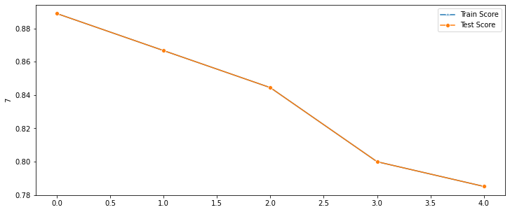

```python
plt.figure(figsize=(12,5))
p = sns.lineplot(range(0,5),df_metrics['7Train-Score'].astype(float),marker='*',label='Train Score')
p = sns.lineplot(range(0,5),df_metrics[7].astype(float),marker='o',label='Test Score')
```

[output not shown]

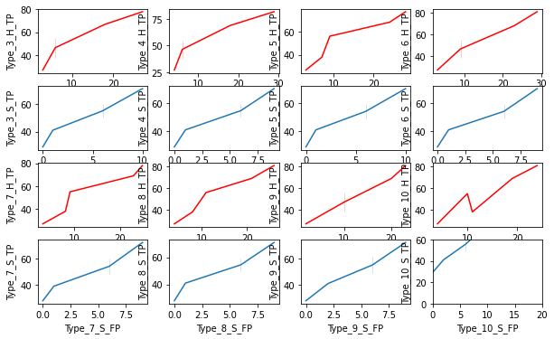

```python
fig_dim = (10,6)
fig, ax = plt.subplots(figsize = (fig_dim))
plt.yticks(rotation=60)

plt.subplot(4,4,1)
sns.lineplot(  data=df_metrics, x = 'Type_3_H_FP', y="Type_3_H_TP",color='red')

plt.subplot(4,4,2)



g = sns.lineplot(  data=df_metrics,  x = 'Type_4_H_FP', y ="Type_4_H_TP",color='red')
plt.subplot(4,4,3)

sns.lineplot(  data=df_metrics,  x = 'Type_5_H_FP', y ="Type_5_H_TP",color='red')
plt.subplot(4,4,4)
sns.lineplot(  data=df_metrics,  x = 'Type_6_H_FP', y ="Type_6_H_TP",color='red')

plt.subplot(4,4,5)
sns.lineplot(  data=df_metrics,  x = 'Type_3_S_FP', y ="Type_3_S_TP")

plt.subplot(4,4,6)
sns.lineplot(  data=df_metrics,  x = 'Type_4_S_FP', y ="Type_4_S_TP")
plt.subplot(4,4,7)
sns.lineplot(  data=df_metrics,  x = 'Type_5_S_FP', y ="Type_5_S_TP")
plt.subplot(4,4,8)
sns.lineplot(  data=df_metrics,  x = 'Type_6_S_FP', y ="Type_6_S_TP")

plt.subplot(4,4,9)
sns.lineplot(  data=df_metrics, x = 'Type_7_H_FP', y="Type_7_H_TP",color='red')

plt.subplot(4,4,10)



g = sns.lineplot(  data=df_metrics,  x = 'Type_8_H_FP', y ="Type_8_H_TP",color='red')
plt.subplot(4,4,11)

sns.lineplot(  data=df_metrics,  x = 'Type_9_H_FP', y ="Type_9_H_TP",color='red')
plt.subplot(4,4,12)
sns.lineplot(  data=df_metrics,  x = 'Type_10_H_FP', y ="Type_10_H_TP",color='red')

plt.subplot(4,4,13)
sns.lineplot(  data=df_metrics,  x = 'Type_7_S_FP', y ="Type_7_S_TP")

plt.subplot(4,4,14)
sns.lineplot(  data=df_metrics,  x = 'Type_8_S_FP', y ="Type_8_S_TP")
plt.subplot(4,4,15)
sns.lineplot(  data=df_metrics,  x = 'Type_9_S_FP', y ="Type_9_S_TP")
plt.subplot(4,4,16)
sns.lineplot(  data=df_metrics,  x = 'Type_10_S_FP', y ="Type_10_S_TP")
plt.xlim([0,20])
plt.ylim([0,60])
print("graph ::: TP VS FP for K = 3,5,7 - class S and H")
```

- TPR vs FPR for classes H and S in K (3,4,5,6,7,8,9)

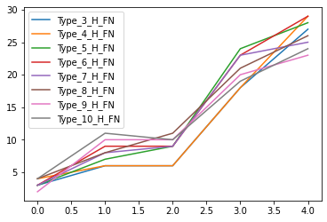

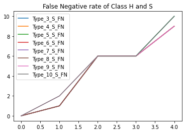

```python
df_metrics[['Type_3_H_FN','Type_4_H_FN','Type_5_H_FN','Type_6_H_FN','Type_7_H_FN','Type_8_H_FN','Type_9_H_FN','Type_10_H_FN']].plot();



df_metrics[['Type_3_S_FN','Type_4_S_FN','Type_5_S_FN','Type_6_S_FN','Type_7_S_FN','Type_8_S_FN','Type_9_S_FN','Type_10_S_FN']].plot();

plt.title("False Negative rate of Class H and S")
```

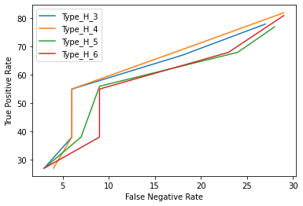

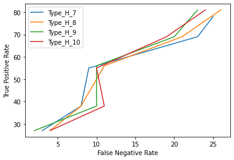

```python
plt.plot( df_metrics['Type_3_H_FN'],df_metrics['Type_3_H_TP'], label = "Type_H_3")
plt.plot( df_metrics['Type_4_H_FN'],df_metrics['Type_4_H_TP'], label = "Type_H_4")
plt.plot( df_metrics['Type_5_H_FN'],df_metrics['Type_5_H_TP'], label = "Type_H_5")
plt.plot(df_metrics['Type_6_H_FN'], df_metrics['Type_6_H_TP'],label = "Type_H_6")
plt.xlabel('False Negative Rate')
plt.ylabel('True Positive Rate')
plt.legend()
plt.show()

plt.plot( df_metrics['Type_7_H_FN'],df_metrics['Type_7_H_TP'], label = "Type_H_7")
plt.plot( df_metrics['Type_8_H_FN'], df_metrics['Type_8_H_TP'],label = "Type_H_8")
plt.plot( df_metrics['Type_9_H_FN'],df_metrics['Type_9_H_TP'], label = "Type_H_9")
plt.plot( df_metrics['Type_10_H_FN'], df_metrics['Type_10_H_TP'],label = "Type_H_10")
plt.xlabel('False Negative Rate')
plt.ylabel('True Positive Rate')
plt.legend(loc='best')
plt.legend()
plt.show()
```

*Neighbour 7 is performing well for both classes H and S comparatively* Neighbour 9 also seems to have less false negative rate , so lets compare both

```python
NNH = KNeighborsClassifier(metric='euclidean', n_neighbors=9, weights='distance')
X_train, X_test, y_train, y_test = train_test_split(XScaled, y_scaled, test_size=0.3, random_state=1)
NNH.fit(X_train, y_train)
predicted_labels = NNH.predict(X_test)
print("Classification report for n = 9\n\n",classification_report(y_test, predicted_labels,labels=[0, 1, 2]))
NNH1 = KNeighborsClassifier(metric='euclidean', n_neighbors=7, weights='distance')
X_train, X_test, y_train, y_test = train_test_split(XScaled, y_scaled, test_size=0.3, random_state=1)
NNH1.fit(X_train, y_train)
predicted_labels = NNH1.predict(X_test)
NNH.score(X_test, y_test)
print("Classification report for n = 7\n\n",classification_report(y_test, predicted_labels,labels=[0, 1, 2]))
```

```
Classification report for n = 9

               precision    recall  f1-score   support

           0       0.79      0.97      0.87        39
           1       0.84      0.82      0.83        45
           2       0.95      0.80      0.87        51

    accuracy                           0.86       135
   macro avg       0.86      0.87      0.86       135
weighted avg       0.87      0.86      0.86       135

Classification report for n = 7

               precision    recall  f1-score   support

           0       0.83      0.97      0.89        39
           1       0.82      0.89      0.85        45
           2       0.97      0.76      0.86        51

    accuracy                           0.87       135
   macro avg       0.87      0.88      0.87       135
weighted avg       0.88      0.87      0.87       135
```

```
0.6258401410516753 0.9549130716243098 0.9690384382622944 14 14
```

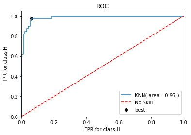

```python
from sklearn.metrics import roc_auc_score
from sklearn.metrics import roc_curve
from numpy import sqrt,argmax
logit_roc_auc = roc_auc_score(y_test,NNH.predict_proba(X_test), multi_class='ovr')
fpr,tpr,threshold = roc_curve(y_test,NNH.predict_proba(X_test)[:,0],pos_label=0)
gmeans = sqrt(tpr*1-fpr)
ix = argmax(gmeans)
print(threshold[ix],gmeans[ix],logit_roc_auc,ix,argmax(gmeans) )
plt.figure()
plt.plot(fpr,tpr,label = 'KNN( area= %0.2f )' % logit_roc_auc)
plt.plot([0,1],[0,1],'r--',label = 'No Skill')
plt.scatter(fpr[ix],tpr[ix],marker ='o',color = 'black',label ='best')
plt.xlim([0.0,1.0])
plt.ylim([0.0,1.05])
plt.xlabel("FPR for class H")
plt.ylabel("TPR for class H")
plt.title('ROC')
plt.legend(loc='lower right')
plt.show()
```

```
0.09794479293606229 0.9515577674917848 0.9690384382622944 8 8
```

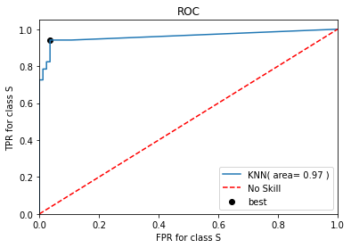

```python
from sklearn.metrics import roc_auc_score
from sklearn.metrics import roc_curve
from numpy import sqrt,argmax
logit_roc_auc = roc_auc_score(y_test,NNH.predict_proba(X_test), multi_class='ovr')
fpr,tpr,threshold = roc_curve(y_test,NNH.predict_proba(X_test)[:,2],pos_label=2)
gmeans = sqrt(tpr*1-fpr)
ix = argmax(gmeans)
print(threshold[ix],gmeans[ix],logit_roc_auc,ix,argmax(gmeans) )
plt.figure()
plt.plot(fpr,tpr,label = 'KNN( area= %0.2f )' % logit_roc_auc)
plt.plot([0,1],[0,1],'r--',label = 'No Skill')
plt.scatter(fpr[ix],tpr[ix],marker ='o',color = 'black',label ='best')
plt.xlim([0.0,1.0])
plt.ylim([0.0,1.05])
plt.xlabel("FPR for class S")
plt.ylabel("TPR for class S")
plt.title('ROC')
plt.legend(loc='lower right')
plt.show()
```

```
0.09794479293606229 0.9515577674917848 0.9690384382622944 8 8
```

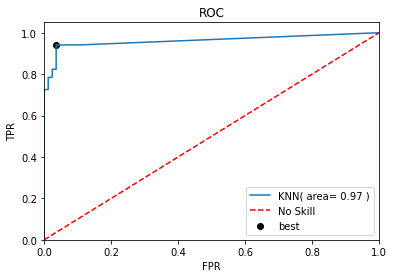

```python
from sklearn.metrics import roc_auc_score
from sklearn.metrics import roc_curve
from numpy import sqrt,argmax
logit_roc_auc = roc_auc_score(y_test,NNH.predict_proba(X_test), multi_class='ovr')
fpr,tpr,threshold = roc_curve(y_test,NNH.predict_proba(X_test)[:,2],pos_label=2)
gmeans = sqrt(tpr*1-fpr)
ix = argmax(gmeans)
print(threshold[ix],gmeans[ix],logit_roc_auc,ix,argmax(gmeans) )
plt.figure()
plt.plot(fpr,tpr,label = 'KNN( area= %0.2f )' % logit_roc_auc)
plt.plot([0,1],[0,1],'r--',label = 'No Skill')
plt.scatter(fpr[ix],tpr[ix],marker ='o',color = 'black',label ='best')
plt.xlim([0.0,1.0])
plt.ylim([0.0,1.05])
plt.xlabel("FPR")
plt.ylabel("TPR")
plt.title('ROC')
plt.legend(loc='lower right')
plt.show()
```

###### Quality

# Classfy customers who might be a customers with loan on card using logistic regression and Naive Bayes

```python
import pandas as pd
import numpy as np
import matplotlib.pyplot as plt
import seaborn as sns
%matplotlib inline
from statsmodels.stats.proportion import proportions_ztest
from sklearn.model_selection import train_test_split
from sklearn import metrics
from sklearn.linear_model import LogisticRegression
from sklearn.naive_bayes import GaussianNB
```

# 1. Import and warehouse data:

a. Import all the given datasets and explore shape and size of each.

```python
Data_Part1 = pd.read_csv('Part2 - Data1.csv')
Data_Part2 = pd.read_csv('Part2 -Data2.csv')
print("data part 1",Data_Part1.head())
print("data part 2",Data_Part2.head())
print('\n\n\nshape of part1 dataframe is ', Data_Part1.shape, 'and part2 dataframe is ', Data_Part2.shape)
```

```
data part 1    ID  Age  CustomerSince  HighestSpend  ZipCode  HiddenScore  \
0   1   25              1            49    91107            4
1   2   45             19            34    90089            3
2   3   39             15            11    94720            1
3   4   35              9           100    94112            1
4   5   35              8            45    91330            4

   MonthlyAverageSpend  Level
0                  1.6      1
1                  1.5      1
2                  1.0      1
3                  2.7      2
4                  1.0      2
data part 2    ID  Mortgage  Security  FixedDepositAccount  InternetBanking  CreditCard  \
0   1         0         1                    0                0           0
1   2         0         1                    0                0           0
2   3         0         0                    0                0           0
3   4         0         0                    0                0           0
4   5         0         0                    0                0           1

   LoanOnCard
0         NaN
1         NaN
2         NaN
3         NaN
4         NaN



shape of part1 dataframe is  (5000, 8) and part2 dataframe is  (5000, 7)
```

b. Merge all datasets onto one and explore final shape and size.

```python
bank_df1 = pd.merge(Data_Part1, Data_Part2)
print('shape of merged bank dataframe is ', bank_df1.shape)
print("\n\n\ndata frame description",bank_df1.describe())
```

```
shape of merged bank dataframe is  (5000, 14)



data frame description                 ID          Age  CustomerSince  HighestSpend       ZipCode  \
count  5000.000000  5000.000000    5000.000000   5000.000000   5000.000000
mean   2500.500000    45.338400      20.104600     73.774200  93152.503000
std    1443.520003    11.463166      11.467954     46.033729   2121.852197
min       1.000000    23.000000      -3.000000      8.000000   9307.000000
25%    1250.750000    35.000000      10.000000     39.000000  91911.000000
50%    2500.500000    45.000000      20.000000     64.000000  93437.000000
75%    3750.250000    55.000000      30.000000     98.000000  94608.000000
max    5000.000000    67.000000      43.000000    224.000000  96651.000000

       HiddenScore  MonthlyAverageSpend        Level     Mortgage  \
count  5000.000000          5000.000000  5000.000000  5000.000000
mean      2.396400             1.937938     1.881000    56.498800
std       1.147663             1.747659     0.839869   101.713802
min       1.000000             0.000000     1.000000     0.000000
25%       1.000000             0.700000     1.000000     0.000000
50%       2.000000             1.500000     2.000000     0.000000
75%       3.000000             2.500000     3.000000   101.000000
max       4.000000            10.000000     3.000000   635.000000

          Security  FixedDepositAccount  InternetBanking   CreditCard  \
count  5000.000000           5000.00000      5000.000000  5000.000000
mean      0.104400              0.06040         0.596800     0.294000
std       0.305809              0.23825         0.490589     0.455637
min       0.000000              0.00000         0.000000     0.000000
25%       0.000000              0.00000         0.000000     0.000000
50%       0.000000              0.00000         1.000000     0.000000
75%       0.000000              0.00000         1.000000     1.000000
max       1.000000              1.00000         1.000000     1.000000

        LoanOnCard
count  4980.000000
mean      0.096386
std       0.295149
min       0.000000
25%       0.000000
50%       0.000000
75%       0.000000
max       1.000000
```

# 2. Data cleansing:

a. Explore and if required correct the datatypes of each attribute

```python
bank_df1.dtypes
```

```
ID                       int64
Age                      int64
CustomerSince            int64
HighestSpend             int64
ZipCode                  int64
HiddenScore              int64
MonthlyAverageSpend    float64
Level                    int64
Mortgage                 int64
Security                 int64
FixedDepositAccount      int64
InternetBanking          int64
CreditCard               int64
LoanOnCard             float64
dtype: object
```

- Loan on Card has null values , dropping null values - 20 records from 5000 records
- correcting data types of few columns

### Changing data type

```python
from pandas.api.types import CategoricalDtype
#CategoricalDtype(categories=["b", "c", "d"], ordered=True)
Hs = CategoricalDtype(categories=[1, 2, 3,4], ordered=True)
bank_df1['ZipCode'] = bank_df1['ZipCode'].astype('str')
bank_df1['HiddenScore'] = bank_df1['HiddenScore'].astype(CategoricalDtype(categories=[1, 2, 3,4], ordered=True))
bank_df1['Level'] = bank_df1['Level'].astype(CategoricalDtype(categories=[1, 2, 3], ordered=True))
bank_df1['Security'] = bank_df1['Security'].astype("category")
bank_df1['FixedDepositAccount'] = bank_df1['FixedDepositAccount'].astype("category")
bank_df1['InternetBanking'] = bank_df1['InternetBanking'].astype("category")
bank_df1['CreditCard'] = bank_df1['CreditCard'].astype("category")
bank_df1['LoanOnCard']=bank_df1['LoanOnCard'].astype("category")
```

```python
bank_df1.dtypes
```

```
ID                        int64
Age                       int64
CustomerSince             int64
HighestSpend              int64
ZipCode                  object
HiddenScore            category
MonthlyAverageSpend     float64
Level                  category
Mortgage                  int64
Security               category
FixedDepositAccount    category
InternetBanking        category
CreditCard             category
LoanOnCard             category
dtype: object
```

```python
bank_df1.head()
```

|  | ID | Age | CustomerSince | HighestSpend | ZipCode | HiddenScore | MonthlyAverageSpend | Level | Mortgage | Security | FixedDepositAccount | InternetBanking | CreditCard | LoanOnCard |
| --- | --- | --- | --- | --- | --- | --- | --- | --- | --- | --- | --- | --- | --- | --- |
| 0 | 1 | 25 | 1 | 49 | 91107 | 4 | 1.6 | 1 | 0 | 1 | 0 | 0 | 0 | NaN |
| 1 | 2 | 45 | 19 | 34 | 90089 | 3 | 1.5 | 1 | 0 | 1 | 0 | 0 | 0 | NaN |
| 2 | 3 | 39 | 15 | 11 | 94720 | 1 | 1.0 | 1 | 0 | 0 | 0 | 0 | 0 | NaN |
| 3 | 4 | 35 | 9 | 100 | 94112 | 1 | 2.7 | 2 | 0 | 0 | 0 | 0 | 0 | NaN |
| 4 | 5 | 35 | 8 | 45 | 91330 | 4 | 1.0 | 2 | 0 | 0 | 0 | 0 | 1 | NaN |

```python
#dropping null values
print("\n\n null values in dataframe",bank_df1.isna().sum())
bank_df1.dropna(axis = 0, inplace =True)
print("\n\n is there nay null value in data frame",bank_df1.isnull().values.any())
print("\n\n shape of cleaned data frame",bank_df1.shape)
```

```
 null values in dataframe ID                      0
Age                     0
CustomerSince           0
HighestSpend            0
ZipCode                 0
HiddenScore             0
MonthlyAverageSpend     0
Level                   0
Mortgage                0
Security                0
FixedDepositAccount     0
InternetBanking         0
CreditCard              0
LoanOnCard             20
dtype: int64


 is there nay null value in data frame False


 shape of cleaned data frame (4980, 14)
```

```python
num_col = bank_df1[['ID','Age','CustomerSince','HighestSpend','MonthlyAverageSpend','Mortgage','LoanOnCard']]
```

```python
cat_col = bank_df1[['HiddenScore','Level','Security','FixedDepositAccount','InternetBanking','CreditCard','LoanOnCard']]
```